# Overview statistic tests PB

Jonas van Nijnatten

21 november 2018

contact: J.J.vanNijnatten@uva.nl

source code: https://github.com/jonasvannijnatten/R_Data_Visualization

# 1 R and package versions

## 1.1 Versions

software versions used for this tutorial:  
- R version 3.5.1 (2018-07-02)  
- car-package version: 3.0.0 (2018-03-23)  
- ez-package version: 4.4.0 (2016-11-01)

## 1.2 Installation

Download & install the required packages:

```r
install.packages(pkgs="kableExtra",   repos="https://www.freestatistics.org/cran/")
install.packages(pkgs="car",   repos="https://www.freestatistics.org/cran/")
install.packages(pkgs="ez",    repos="https://www.freestatistics.org/cran/")
```

Activate required packages:

```r
library(package=kableExtra)
library(package=car)
library(package=ez)
```

# 2 T-test

## 2.1 Independent samples T-test

**Show code for data generation**

```r
# generate data
N = 40
data.long = data.frame(
  ID = 1:N,
  condition = rep(x = c("A","B"), each = N),
  score = c(rnorm(n = N, mean = 25, sd = 6.5), rnorm(n = N, mean = 35, sd = 6.5))
)
```

data.long

| ID | condition | score |
| --- | --- | --- |
| 1 | A | 23.201904 |
| 2 | A | 14.266330 |
| 3 | A | 8.621243 |
| 4 | A | 29.027246 |
| 5 | A | 29.579401 |
| 1 | B | 27.244878 |
| 2 | B | 26.859362 |
| 3 | B | 28.831089 |
| 4 | B | 28.833435 |
| 5 | B | 35.774737 |

Test assumption of normality

```r
by(data = data.long$score, INDICES = data.long$condition, FUN = shapiro.test)
```

```
## data.long$condition: A
##
##  Shapiro-Wilk normality test
##
## data:  dd[x, ]
## W = 0.97983, p-value = 0.6832
##
## --------------------------------------------------------
## data.long$condition: B
##
##  Shapiro-Wilk normality test
##
## data:  dd[x, ]
## W = 0.95376, p-value = 0.1022
```

Test assumption of equality of variances

```r
leveneTest(y = data.long$score, group = data.long$condition)
```

```
## Levene's Test for Homogeneity of Variance (center = median)
##       Df F value Pr(>F)
## group  1  0.1418 0.7075
##       78
```

**T-test**

```r
t.test(formula = score ~ condition, data = data.long, paired=FALSE, alternative="two.sided", var.equal=TRUE)
```

```
##
##  Two Sample t-test
##
## data:  score by condition
## t = -10.04, df = 78, p-value = 1.057e-15
## alternative hypothesis: true difference in means is not equal to 0
## 95 percent confidence interval:
##  -13.967694  -9.344972
## sample estimates:
## mean in group A mean in group B
##        22.58512        34.24145
```

## 2.2 Paired samples T-test

**Show code for data generation**

```r
# generate data
N = 30
data.long = data.frame(
  ID = rep(1:N,2),
  condition = rep(x = c("A","B"), each = N),
  score = c(rnorm(n = N, mean = 25, sd = 6.5), rnorm(n = N, mean = 35, sd = 6.5))
)
```

data.long

| ID | condition | score |
| --- | --- | --- |
| 1 | A | 31.15873 |
| 2 | A | 27.95118 |
| 3 | A | 28.49009 |
| 4 | A | 23.80103 |
| 5 | A | 24.47103 |
| 1 | B | 34.41360 |
| 2 | B | 31.88772 |
| 3 | B | 30.69841 |
| 4 | B | 45.75507 |
| 5 | B | 43.74554 |

Test assumption of normality

```r
# calculate difference scores
diffScore = data.long$score[data.long$condition=="A"] - data.long$score[data.long$condition=="B"]
shapiro.test(diffScore)
```

```
##
##  Shapiro-Wilk normality test
##
## data:  diffScore
## W = 0.96023, p-value = 0.314
```

**T-test**

```r
t.test(formula = score ~ condition, data = data.long, paired=TRUE, alternative="two.sided", var.equal=TRUE)
```

```
##
##  Paired t-test
##
## data:  score by condition
## t = -7.6322, df = 29, p-value = 2.049e-08
## alternative hypothesis: true difference in means is not equal to 0
## 95 percent confidence interval:
##  -15.342988  -8.857818
## sample estimates:
## mean of the differences
##                -12.1004
```

# 3 Correlation

**Show code for data generation**

```r
# generate data
set.seed(05)
nrobs = 100
experience = rnorm(n = nrobs, mean = 15, sd = 3)
salary     = 10000 + ( 5 * experience ) + rnorm(n = nrobs, mean = 0, sd = 100)
data.long = data.frame(experience, salary)
# calculate correlation coefficient r
corr_coef = cor(x = data.long$experience, y = data.long$salary)
rm(list = c("nrobs", "experience", "salary"))
```

data.long

| experience | salary |
| --- | --- |
| 12.47743 | 9862.848 |
| 19.15308 | 10209.297 |
| 11.23352 | 10123.747 |
| 15.21043 | 10096.900 |
| 20.13432 | 10094.887 |

Test assumption of normality

```r
apply(X = data.long, MARGIN = 2, FUN = shapiro.test)
```

```
## $experience
##
##  Shapiro-Wilk normality test
##
## data:  newX[, i]
## W = 0.98711, p-value = 0.445
##
##
## $salary
##
##  Shapiro-Wilk normality test
##
## data:  newX[, i]
## W = 0.99257, p-value = 0.8607
```

**Pearson correlation**

```r
cor.test(x=data.long$experience, y=data.long$salary, alternative = "two.sided", method = "pearson")
```

```
##
##  Pearson's product-moment correlation
##
## data:  data.long$experience and data.long$salary
## t = 2.5509, df = 98, p-value = 0.01229
## alternative hypothesis: true correlation is not equal to 0
## 95 percent confidence interval:
##  0.05584335 0.42510763
## sample estimates:
##       cor
## 0.2495245
```

**Spearman correlation**

```r
cor.test(x=data.long$experience, y=data.long$salary, alternative = "two.sided", method = "spearman")
```

```
##
##  Spearman's rank correlation rho
##
## data:  data.long$experience and data.long$salary
## S = 121190, p-value = 0.006181
## alternative hypothesis: true rho is not equal to 0
## sample estimates:
##       rho
## 0.2727873
```

# 4 Regression

**Show code for data generation**

```r
# generate data
set.seed(05)
nrobs = 100
experience = rnorm(n = nrobs, mean = 15, sd = 3)
salary     = 10000 + ( 5 * experience ) + rnorm(n = nrobs, mean = 0, sd = 100)
data.long = data.frame(experience, salary)
# calculate correlation coefficient r
corr_coef = cor(x = data.long$experience, y = data.long$salary)
rm(list = c("nrobs", "experience", "salary"))
```

data.long

| experience | salary |
| --- | --- |
| 12.47743 | 9862.848 |
| 19.15308 | 10209.297 |
| 11.23352 | 10123.747 |
| 15.21043 | 10096.900 |
| 20.13432 | 10094.887 |

Fit linear model

```r
linearModel = lm(formula = salary ~ experience, data = data.long)
```

Test assumption of normality & equal variances

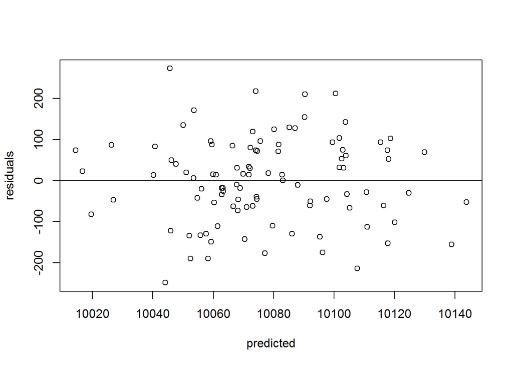

```r
# plot the residuals and look at the distribution around the 0-line and if the spread is equal over all x's.
plot(x=linearModel$fitted.values, y=linearModel$residuals, xlab = "predicted", ylab = "residuals"); abline(h=0)
```

```r
shapiro.test(linearModel$residuals)
```

```
##
##  Shapiro-Wilk normality test
##
## data:  linearModel$residuals
## W = 0.99208, p-value = 0.8268
```

**Regression test**

```r
summary(linearModel)
```

```
##
## Call:
## lm(formula = salary ~ experience, data = data.long)
##
## Residuals:
##     Min      1Q  Median      3Q     Max
## -248.24  -61.55   10.13   74.34  273.17
##
## Coefficients:
##             Estimate Std. Error t value Pr(>|t|)
## (Intercept) 9934.674     56.812 174.870   <2e-16 ***
## experience     9.437      3.700   2.551   0.0123 *
## ---
## Signif. codes:  0 '***' 0.001 '**' 0.01 '*' 0.05 '.' 0.1 ' ' 1
##
## Residual standard error: 104.4 on 98 degrees of freedom
## Multiple R-squared:  0.06226,    Adjusted R-squared:  0.05269
## F-statistic: 6.507 on 1 and 98 DF,  p-value: 0.01229
```

# 5 Logistic regression

**Show code for data generation**

```r
set.seed(01)
N = 30
data.long = data.frame(
  x = 1:N,
  y = round( 1 / (1 + exp(-.23*(1:N-10)))  +  # logistic function of x
               rnorm(n = N, mean = 0, sd = .3) # add some noise
             ) # round it to either 1 or 0
  )
```

```r
# fit a logistic model, which is a generalized linear model, hence glm() function
glm.fit <- glm(y ~ x, data = data.long, family = binomial('logit'))
# test the logistic model against the NULL model
anova(glm.fit, test="Chisq")
```

```
## Analysis of Deviance Table
##
## Model: binomial, link: logit
##
## Response: y
##
## Terms added sequentially (first to last)
##
##
##      Df Deviance Resid. Df Resid. Dev  Pr(>Chi)
## NULL                    29     38.191
## x     1   11.329        28     26.862 0.0007631 ***
## ---
## Signif. codes:  0 '***' 0.001 '**' 0.01 '*' 0.05 '.' 0.1 ' ' 1
```

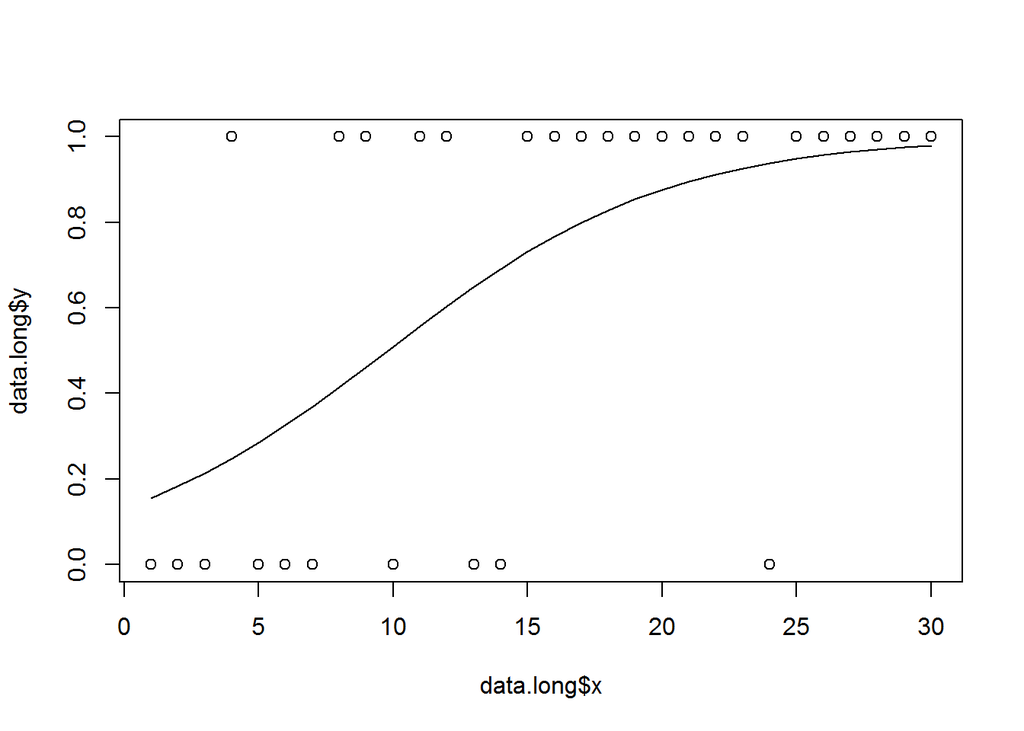

```r
plot(data.long$x, data.long$y) # plot the measured data
lines(formula = glm.fit$fitted.values ~ data.long$x) # plot the fitted model
```

# 6 One-way independent samples ANOVA

**Toon code om voorbeeld data te genereren**

```r
set.seed(05)   # set seed
nrofconds = 3  # set number of conditions
nrofsubs  = 20 # set number of subjects
subj = as.factor(1:(nrofsubs*nrofconds))      # create array with subject IDs
condition = as.factor(rep(LETTERS[1:nrofconds],each=nrofsubs))   # create array with condition values
score = as.vector( replicate(
          nrofconds , rnorm(n = nrofsubs, mean = sample(8,1)+10 , sd = sample(5,1) )
        ) )                                     # create array with measurement values
data.long = data.frame(subj, condition, score);      # combine arrays into a data.frame
rm(list=c("subj", "condition","score","nrofconds","nrofsubs")) # delete unnecessary variables
```

data.long

| subj | condition | score |
| --- | --- | --- |
| 1 | A | 17.537437 |
| 2 | A | 6.978033 |
| 21 | B | 21.403886 |
| 22 | B | 19.120283 |
| 41 | C | 15.895668 |
| 42 | C | 13.543431 |

## 6.1 Checking assumptions

Test assumption of normality

```r
by(data = data.long$score, INDICES = data.long$condition, FUN = shapiro.test)
```

```
## data.long$condition: A
##
##  Shapiro-Wilk normality test
##
## data:  dd[x, ]
## W = 0.9637, p-value = 0.6201
##
## --------------------------------------------------------
## data.long$condition: B
##
##  Shapiro-Wilk normality test
##
## data:  dd[x, ]
## W = 0.92868, p-value = 0.1456
##
## --------------------------------------------------------
## data.long$condition: C
##
##  Shapiro-Wilk normality test
##
## data:  dd[x, ]
## W = 0.94927, p-value = 0.3561
```

Test equality of variances

```r
leveneTest(y = data.long$score, group = data.long$condition)
```

```
## Levene's Test for Homogeneity of Variance (center = median)
##       Df F value    Pr(>F)
## group  2  8.9065 0.0004306 ***
##       57
## ---
## Signif. codes:  0 '***' 0.001 '**' 0.01 '*' 0.05 '.' 0.1 ' ' 1
```

## 6.2 Running the test

**ANOVA*** with the aov method

```r
aovModel = aov(formula = score ~ condition, data = data.long)
summary(aovModel)
```

```
##             Df Sum Sq Mean Sq F value   Pr(>F)
## condition    2  475.4  237.69   24.88 1.71e-08 ***
## Residuals   57  544.5    9.55
## ---
## Signif. codes:  0 '***' 0.001 '**' 0.01 '*' 0.05 '.' 0.1 ' ' 1
```

**ANOVA*** with the linear model method

```r
lmModel = lm(formula = score ~ condition, data = data.long)
summary(lmModel)
```

```
##
## Call:
## lm(formula = score ~ condition, data = data.long)
##
## Residuals:
##     Min      1Q  Median      3Q     Max
## -7.9619 -1.5380 -0.1243  1.4997  7.6197
##
## Coefficients:
##             Estimate Std. Error t value Pr(>|t|)
## (Intercept)  11.2260     0.6911  16.243  < 2e-16 ***
## conditionB    6.8584     0.9774   7.017 2.98e-09 ***
## conditionC    2.8167     0.9774   2.882  0.00557 **
## ---
## Signif. codes:  0 '***' 0.001 '**' 0.01 '*' 0.05 '.' 0.1 ' ' 1
##
## Residual standard error: 3.091 on 57 degrees of freedom
## Multiple R-squared:  0.4661, Adjusted R-squared:  0.4474
## F-statistic: 24.88 on 2 and 57 DF,  p-value: 1.708e-08
```

## 6.3 Post-hoc analysis

When using the aov method, use the Tukey post-hoc test

```r
TukeyHSD(aovModel)
```

```
##   Tukey multiple comparisons of means
##     95% family-wise confidence level
##
## Fit: aov(formula = score ~ condition, data = data.long)
##
## $condition
##          diff        lwr       upr     p adj
## B-A  6.858389  4.5063749  9.210403 0.0000000
## C-A  2.816672  0.4646584  5.168687 0.0151422
## C-B -4.041717 -6.3937306 -1.689702 0.0003426
```

When using the linear model method, use pairwise t-test

```r
pairwise.t.test(x = data.long$score, g = data.long$condition, paired = FALSE, p.adjust.method = "bonferroni")
```

```
##
##  Pairwise comparisons using t tests with pooled SD
##
## data:  data.long$score and data.long$condition
##
##   A       B
## B 8.9e-09 -
## C 0.01670 0.00035
##
## P value adjustment method: bonferroni
```

# 7 Factorial independent samples ANOVA

**Show code for data generation**

```r
set.seed(01)   # set seed
nrofcondsf1 = 3  # set number of conditions for factor 1
nrofcondsf2 = 2  # set number of conditions for factor 2
nrofsubs    = nrofcondsf1*nrofcondsf2*30 # set number of subjects per condition
subj = as.factor(1:(nrofsubs))      # create array with subject IDs
# create array witht treatment conditions
treatment = as.factor(rep(LETTERS[1:nrofcondsf1],each=nrofsubs/nrofcondsf1))
# create array with control / experimental
control   = as.factor(rep(c("control","experimental"),times=nrofsubs/nrofcondsf2))
# create array with measurement values
score = as.vector( replicate(nrofcondsf1, replicate (
          nrofcondsf2 , rnorm(
            n = (nrofsubs/(nrofcondsf1*nrofcondsf2)),
            mean = 0 , sd = sample(5,1) ) + sample(8,1)+10
        ) ) )
# combine arrays into a data.frame
data.long = data.frame(subj, score, treatment, control);
# delete unnecessary arrays
rm(list=c("control","nrofcondsf1","nrofcondsf2","nrofsubs","score","subj","treatment"))
```

data.long

| subj | score | treatment | control |
| --- | --- | --- | --- |
| 1 | 12.347533 | A | control |
| 2 | 15.659598 | A | experimental |
| 61 | 11.536699 | B | control |
| 62 | 8.740125 | B | experimental |
| 121 | 18.740275 | C | control |
| 122 | 18.493456 | C | experimental |

## 7.1 Fitting the model

Fit model with multiple prediction factors

```r
model = lm(formula = score ~ treatment+control, data = data.long)
```

## 7.2 Checking assumptions

Test assumption of normality

```r
hist(model$residuals)
plot(x = fitted(model), y = residuals(model), xlab="predicted", ylab="residuals"); abline(h=0)
by(data = data.long$score, INDICES = paste(data.long$treatment, data.long$control), FUN = shapiro.test)
```

**Show residuals histogram**

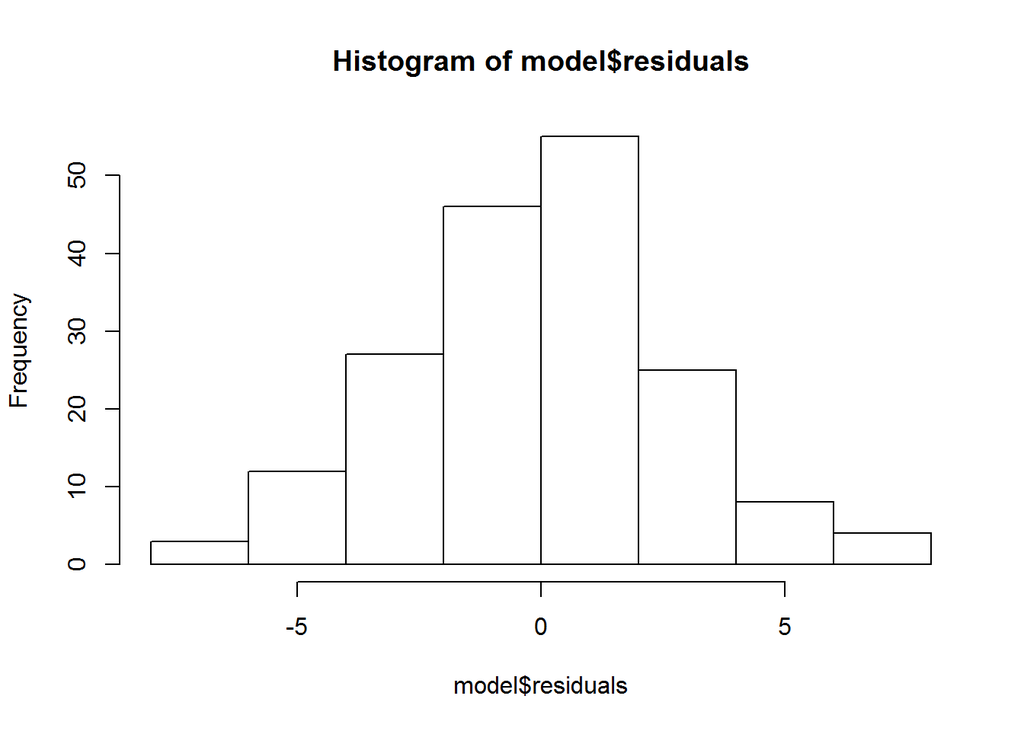

**Show residuals vs predicted plot**

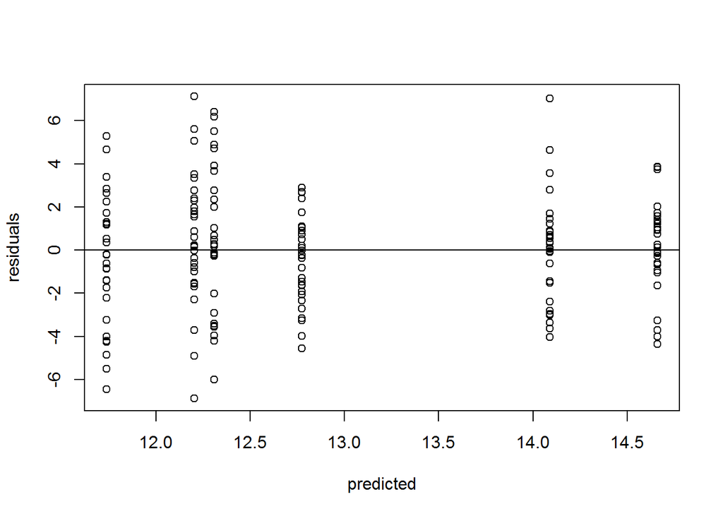

**Show output of Shapiro-Wilk test**

```
## paste(data.long$treatment, data.long$control): A control
##
##  Shapiro-Wilk normality test
##
## data:  dd[x, ]
## W = 0.98372, p-value = 0.9135
##
## --------------------------------------------------------
## paste(data.long$treatment, data.long$control): A experimental
##
##  Shapiro-Wilk normality test
##
## data:  dd[x, ]
## W = 0.97615, p-value = 0.7166
##
## --------------------------------------------------------
## paste(data.long$treatment, data.long$control): B control
##
##  Shapiro-Wilk normality test
##
## data:  dd[x, ]
## W = 0.98224, p-value = 0.8815
##
## --------------------------------------------------------
## paste(data.long$treatment, data.long$control): B experimental
##
##  Shapiro-Wilk normality test
##
## data:  dd[x, ]
## W = 0.95899, p-value = 0.2919
##
## --------------------------------------------------------
## paste(data.long$treatment, data.long$control): C control
##
##  Shapiro-Wilk normality test
##
## data:  dd[x, ]
## W = 0.94015, p-value = 0.09179
##
## --------------------------------------------------------
## paste(data.long$treatment, data.long$control): C experimental
##
##  Shapiro-Wilk normality test
##
## data:  dd[x, ]
## W = 0.93785, p-value = 0.07961
```

Test equality of variances

```r
leveneTest(y = data.long$score, group = as.factor(paste(data.long$treatment, data.long$control)))
```

```
## Levene's Test for Homogeneity of Variance (center = median)
##        Df F value Pr(>F)
## group   5  1.7187 0.1327
##       174
```

## 7.3 Running the test

ANOVA with the linear model method

```r
model = lm(formula = score ~ treatment*control, data = data.long)
library(car)
Anova(mod = model, type = 'II')
```

```
## Anova Table (Type II tests)
##
## Response: score
##                    Sum Sq  Df F value    Pr(>F)
## treatment          185.93   2 12.4027 9.215e-06 ***
## control             14.63   1  1.9521    0.1641
## treatment:control   33.98   2  2.2669    0.1067
## Residuals         1304.25 174
## ---
## Signif. codes:  0 '***' 0.001 '**' 0.01 '*' 0.05 '.' 0.1 ' ' 1
```

```r
summary(model)
```

```
##
## Call:
## lm(formula = score ~ treatment * control, data = data.long)
##
## Residuals:
##     Min      1Q  Median      3Q     Max
## -7.4339 -1.5208  0.1356  1.6227  7.0748
##
## Coefficients:
##                                Estimate Std. Error t value Pr(>|t|)
## (Intercept)                     12.7622     0.4999  25.532   <2e-16 ***
## treatmentB                      -1.5259     0.7069  -2.159   0.0323 *
## treatmentC                       1.2722     0.7069   1.800   0.0737 .
## controlexperimental             -0.5450     0.7069  -0.771   0.4418
## treatmentB:controlexperimental   2.1200     0.9997   2.121   0.0354 *
## treatmentC:controlexperimental   1.2257     0.9997   1.226   0.2218
## ---
## Signif. codes:  0 '***' 0.001 '**' 0.01 '*' 0.05 '.' 0.1 ' ' 1
##
## Residual standard error: 2.738 on 174 degrees of freedom
## Multiple R-squared:  0.1524, Adjusted R-squared:  0.1281
## F-statistic: 6.258 on 5 and 174 DF,  p-value: 2.299e-05
```

## 7.4 Post-hoc analysis

When there are one or more significant main-effects but no significant interaction effect post-hoc comparisons can be made for each factor separately using the pairwise.t.test() function.

Post-hoc comparison for the first factor:

```r
pairwise.t.test(
  x = data.long$score               # column name of the dependent variable
  ,g = data.long$treatment          # column name of the first within-subjects variable
  , paired = FALSE                   # since it is a paired design, set paired=TRUE
  , p.adjust.method = "bonferroni"  # use bonferroni corrected p-values
  )
```

```
##
##  Pairwise comparisons using t tests with pooled SD
##
## data:  data.long$score and data.long$treatment
##
##   A       B
## B 1.00000 -
## C 0.00076 1.9e-05
##
## P value adjustment method: bonferroni
```

Post-hoc comparison for the first factor:

```r
pairwise.t.test(
  x = data.long$score               # column name of the dependent variable
  ,g = data.long$control           # column name of the second within-subjects variable
  , paired = FALSE                   # since it is a paired design, set paired=TRUE
  , p.adjust.method = "bonferroni"  # use bonferroni corrected p-values
  )
```

```
##
##  Pairwise comparisons using t tests with pooled SD
##
## data:  data.long$score and data.long$control
##
##              control
## experimental 0.19
##
## P value adjustment method: bonferroni
```

When the interaction effect turns out significant, pairwise comparisons can be made between all combinations of conditions.

Post-hoc comparison for the interaction effect:

```r
pairwise.t.test(
  x = data.long$score               # column name of the dependent variable
  # merge both factor columns into a combined factor
  ,g = paste(data.long$treatment, data.long$control)
  , paired = FALSE                   # since it is a paired design, set paired=TRUE
  , p.adjust.method = "bonferroni"  # use bonferroni corrected p-values
  )
```

```
##
##  Pairwise comparisons using t tests with pooled SD
##
## data:  data.long$score and paste(data.long$treatment, data.long$control)
##
##                A control A experimental B control B experimental C control
## A experimental 1.0000    -              -         -              -
## B control      0.4839    1.0000         -         -              -
## B experimental 1.0000    1.0000         0.4074    -              -
## C control      1.0000    0.1648         0.0016    1.0000         -
## C experimental 0.0953    0.0079         3e-05     0.1166         1.0000
##
## P value adjustment method: bonferroni
```

# 8 One-way repeated measures ANOVA

**Show code for data generation**

```r
# Generate dataset
set.seed(01)   # set seed
nrofsubs  = 20 # set number of subjects
data.wide = data.frame(
  subj = as.factor(1:nrofsubs)   ,
  A =  rnorm(n = nrofsubs, mean = sample(8,1)+10 , sd = sample(5,1)) ,
  B =  rnorm(n = nrofsubs, mean = sample(8,1)+10 , sd = sample(5,1)) ,
  C =  rnorm(n = nrofsubs, mean = sample(8,1)+10 , sd = sample(5,1))
)
rm(list=c("nrofsubs")) # delete arrays
```

data.wide

| subj | A | B | C |
| --- | --- | --- | --- |
| 1 | 13.36729 | 17.22369 | 18.11333 |
| 2 | 11.32874 | 11.03194 | 15.62249 |
| 3 | 16.19056 | 18.85948 | 15.58501 |
| 4 | 13.65902 | 16.83161 | 17.72916 |

## 8.1 Fitting the model

fit linear model

```r
model = lm(formula = cbind(data.wide$A, data.wide$B, data.wide$C)~1)
```

## 8.2 Checking assumptions

Test assumption of normality

```
##
##  Shapiro-Wilk normality test
##
## data:  model$residuals
## W = 0.97837, p-value = 0.3637
```

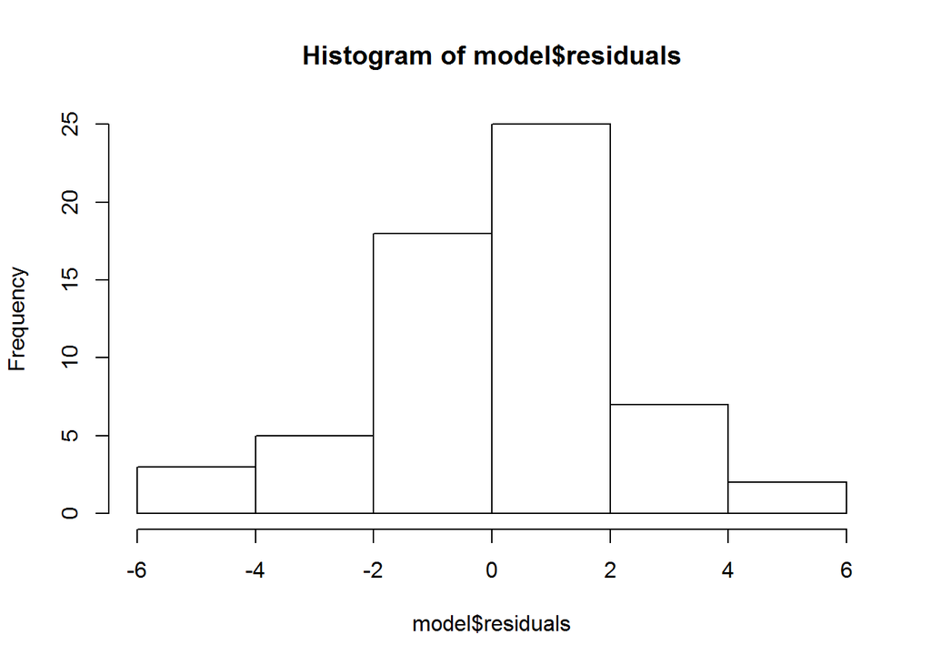

```r
shapiro.test(model$residuals)
hist(model$residuals)
```

Test assumption of sphericity

```r
mauchly.test(model, X=~1)
```

```
##
##  Mauchly's test of sphericity
##  Contrasts orthogonal to
##  ~1
##
##
## data:  SSD matrix from lm(formula = cbind(data.wide$A, data.wide$B, data.wide$C) ~ 1)
## W = 0.88731, p-value = 0.341
```

## 8.3 Running the test

Test the model using ANOVA

```r
anova(model, X = ~1, test="Spherical")
```

```
## Analysis of Variance Table
##
##
## Contrasts orthogonal to
## ~1
##
## Greenhouse-Geisser epsilon: 0.8987
## Huynh-Feldt epsilon:        0.9867
##
##             Df      F num Df den Df     Pr(>F)     G-G Pr     H-F Pr
## (Intercept)  1 21.953      2     38 4.6015e-07 1.4959e-06 5.3683e-07
## Residuals   19
```

## 8.4 Post-hoc analysis

For post-hoc analysis the data has to be transformed to the **long format**

**Show code for reshaping**

```r
# reshape into wide format
data.long = reshape(data = data.wide
                   , direction = 'long'
                   , varying = c("A","B","C")
                   , timevar = 'treatment'
                   , times = c("A","B","C")
                   , v.names = c("score")
                   , idvar = "subj"
                   )
```

Use pairwise T-test to compare each combination of conditions

```r
pairwise.t.test(
  x = data.long$score               # column name of the dependent variable
  ,g = data.long$treatment          # column name of the first within-subjects variable
  , paired = TRUE                   # since it is a paired design, set paired=TRUE
  , p.adjust.method = "bonferroni"  # use bonferroni corrected p-values
  )
```

```
##
##  Pairwise comparisons using paired t tests
##
## data:  data.long$score and data.long$treatment
##
##   A       B
## B 2.9e-05 -
## C 2.3e-05 0.67
##
## P value adjustment method: bonferroni
```

# 9 Factorial repeated measures ANOVA

**Show code for data generation**

```r
set.seed(02)  # set seed
nrofsubs    = 20 # set number of subjects

data.wide = data.frame(
  ID=1:nrofsubs,
  preA=rnorm(n=nrofsubs, mean = 09,sd = 3),
  preB=rnorm(n=nrofsubs, mean = 10,sd = 3),
  preC=rnorm(n=nrofsubs, mean = 11,sd = 3),
  postA=rnorm(n=nrofsubs, mean = 11,sd = 3),
  postB=rnorm(n=nrofsubs, mean = 15,sd = 3),
  postC=rnorm(n=nrofsubs, mean = 20,sd = 3)
)
rm(list="nrofsubs")
```

data.wide

| ID | preA | preB | preC | postA | postB | postC |
| --- | --- | --- | --- | --- | --- | --- |
| 1 | 6.309256 | 16.272458 | 9.849241 | 5.635273 | 17.987954 | 23.22338 |
| 2 | 9.554548 | 6.400222 | 5.122691 | 17.093728 | 9.912705 | 20.78179 |
| 3 | 13.763536 | 14.768915 | 8.474885 | 8.890567 | 13.399884 | 19.05718 |
| 4 | 5.608873 | 15.863955 | 16.710642 | 11.474494 | 10.883192 | 17.75111 |

## 9.1 Fitting the model

Fit linear model to the data, not yet seperating both independent factors:

```r
model = lm(cbind(data.wide$preA,
                 data.wide$preB,
                 data.wide$preC,
                 data.wide$postA,
                 data.wide$postB,
                 data.wide$postC
                 )~1
           )
```

Make a factor matrix clarifying the conditions. Name the colomns as the factors. Use the parts of the column names of the data.frame in the wide format as variable values in the matrix.

```r
factorMatrix = data.frame(
  time=as.factor(rep(c("pre","post"),each=3)),
  condition = as.factor(rep(c("A","B","C"),2))
)
```

fit linear model specifying the two independent variables using the factorMatrix

```r
library(car)
factorialAnova = Anova(mod=model, idata=factorMatrix, idesign= ~time*condition, type='III')
```

## 9.2 Checking assumptions

```
##
##  Shapiro-Wilk normality test
##
## data:  model$residuals
## W = 0.98072, p-value = 0.08312
```

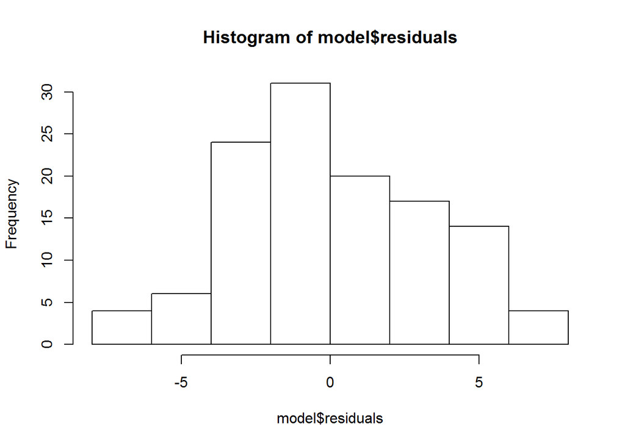

```r
shapiro.test(model$residuals)
hist(model$residuals)
```

## 9.3 Running the test

run the factorial ANOVA

```r
summary(object = factorialAnova, multivariate=FALSE)
```

```
##
## Univariate Type III Repeated-Measures ANOVA Assuming Sphericity
##
##                 Sum Sq num Df Error SS den Df  F value    Pr(>F)
## (Intercept)    19546.1      1   176.39     19 2105.421 < 2.2e-16 ***
## time             733.4      1   246.98     19   56.421 4.218e-07 ***
## condition        777.6      2   483.72     38   30.543 1.235e-08 ***
## time:condition   400.6      2   417.36     38   18.235 2.807e-06 ***
## ---
## Signif. codes:  0 '***' 0.001 '**' 0.01 '*' 0.05 '.' 0.1 ' ' 1
##
##
## Mauchly Tests for Sphericity
##
##                Test statistic p-value
## condition             0.98514 0.87398
## time:condition        0.96336 0.71466
##
##
## Greenhouse-Geisser and Huynh-Feldt Corrections
##  for Departure from Sphericity
##
##                 GG eps Pr(>F[GG])
## condition      0.98536  1.541e-08 ***
## time:condition 0.96466  3.983e-06 ***
## ---
## Signif. codes:  0 '***' 0.001 '**' 0.01 '*' 0.05 '.' 0.1 ' ' 1
##
##                  HF eps   Pr(>F[HF])
## condition      1.098534 1.235183e-08
## time:condition 1.071609 2.806538e-06
```

The Mauchly Test checks each factor on the assumption of sphericity. If the Mauchly Test shows a significant result for any of the factors or interaction between factors then a corrected p=value should be used instead of the normal, uncorrected p-value.

## 9.4 Post-hoc analysis

For post-hoc analysis the data has to be transformed to the **long format**

**Show code for reshaping**

```r
# reshape into wide format
data.mix = reshape(data = data.wide
                   , direction = 'long'
                   , varying = list(c('preA','preB','preC'),c('postA','postB','postC'))
                   , timevar = 'treatment'
                   , times = c("A","B","C")
                   , v.names = c("pre","post")
                   , idvar = "ID"
                   )
data.long = reshape(data = data.mix
                   , direction = 'long'
                   , varying = c("pre","post")
                   , timevar = 'pre_post'
                   , times = c("pre","post")
                   , v.names = "score"
                   , idvar = c("ID", "treatment")
                   )
```

When there are one or more significant main-effects but no significant interaction effect post-hoc comparisons can be made for each factor separately using the pairwise.t.test() function.

Post-hoc comparison for the first factor:

```r
pairwise.t.test(
  x = data.long$score               # column name of the dependent variable
  ,g = data.long$treatment          # column name of the first within-subjects variable
  , paired = TRUE                   # since it is a paired design, set paired=TRUE
  , p.adjust.method = "bonferroni"  # use bonferroni corrected p-values
  )
```

```
##
##  Pairwise comparisons using paired t tests
##
## data:  data.long$score and data.long$treatment
##
##   A       B
## B 0.06089 -
## C 1.2e-06 0.00012
##
## P value adjustment method: bonferroni
```

Post-hoc comparison for the first factor:

```r
pairwise.t.test(
  x = data.long$score               # column name of the dependent variable
  ,g = data.long$pre_post           # column name of the second within-subjects variable
  , paired = TRUE                   # since it is a paired design, set paired=TRUE
  , p.adjust.method = "bonferroni"  # use bonferroni corrected p-values
  )
```

```
##
##  Pairwise comparisons using paired t tests
##
## data:  data.long$score and data.long$pre_post
##
##     post
## pre 3.1e-08
##
## P value adjustment method: bonferroni
```

When the interaction effect turns out significant, pairwise comparisons can be made between all combinations of conditions.

Post-hoc comparison for the interaction effect:

```r
pairwise.t.test(
  x = data.long$score               # column name of the dependent variable
  # merge both factor columns into a combined factor
  ,g = paste(data.long$treatment, data.long$pre_post)
  , paired = TRUE                   # since it is a paired design, set paired=TRUE
  , p.adjust.method = "bonferroni"  # use bonferroni corrected p-values
  )
```

```
##
##  Pairwise comparisons using paired t tests
##
## data:  data.long$score and paste(data.long$treatment, data.long$pre_post)
##
##        A post  A pre   B post  B pre   C post
## A pre  1.0000  -       -       -       -
## B post 0.0971  0.0031  -       -       -
## B pre  1.0000  1.0000  0.0505  -       -
## C post 1.3e-08 1.5e-08 1.0e-05 4.8e-07 -
## C pre  1.0000  1.0000  0.2321  1.0000  2.6e-07
##
## P value adjustment method: bonferroni
```

# 10 Mixed-Design ANOVA

**Show code for data generation**

```r
set.seed(02)   # set seed
nrofcondsf1 = 3  # set number of conditions for factor 1
nrofcondsf2 = 2  # set number of conditions for factor 2
nrofsubs    = 30 # set number of subjects per condition
subj = as.factor(rep(x= 1:(nrofsubs*nrofcondsf2), times=nrofcondsf1))       # create array with subject IDs
# create array witht treatment conditions
treatment = as.factor(rep(LETTERS[1:nrofcondsf1],each=nrofsubs*nrofcondsf2))
# create array with control / experimental
gender   = as.factor(rep(c("men","women"),times=nrofsubs*nrofcondsf1))
# create array with measurement values
score = as.vector( replicate(nrofcondsf1, replicate (
          nrofcondsf2 , rnorm(
            n = (nrofsubs),
            mean = 0 , sd = sample(5,1) ) + sample(8,1)+10
        ) ) )
# combine arrays into a data.frame
data.long = data.frame(subj, score, treatment, gender);
# delete unnecessary arrays
rm(list=c("gender","nrofcondsf1","nrofcondsf2","nrofsubs","score","subj","treatment"))
```

data.long

| subj | score | treatment | gender |
| --- | --- | --- | --- |
| 1 | 18.531241 | A | men |
| 2 | 17.038108 | A | women |
| 1 | 18.394722 | B | men |
| 2 | 15.980442 | B | women |
| 1 | 10.633027 | C | men |
| 2 | 9.597652 | C | women |

## 10.1 Fitting the model

Fit mixed-model using ezANOVA() function

```r
mix.model = ezANOVA(data = data.long      # name of the data frame (long format)
                    , dv = score          # column name of the dependent variabele
                    , wid = subj          # column name indicating subject ID
                    , within = treatment  # column name of the within factor
                    , between = gender    # column name of the between factor
                    , return_aov = TRUE   # add information to the output for normality testing
                    )
```

## 10.2 Checking assumptions

Test assumption of normality of the residuals

```
##
##  Shapiro-Wilk normality test
##
## data:  mix.model$aov$`subj:treatment`$residuals
## W = 0.98281, p-value = 0.1298
```

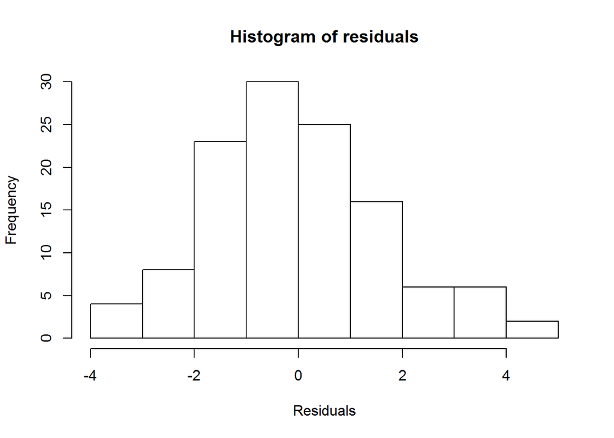

```r
shapiro.test(mix.model$aov$`subj:treatment`$residuals)

hist(mix.model$aov$`subj:treatment`$residuals
     , xlab = 'Residuals'
     , main = 'Histogram of residuals')
```

Test assumption of sphericity

```r
mix.model$`Mauchly's Test for Sphericity`
```

```
##             Effect         W          p p<.05
## 3        treatment 0.9197104 0.09205689
## 4 gender:treatment 0.9197104 0.09205689
```

## 10.3 Running the test

If the assumption of sphericity is met use the normal, uncorrected ANOVA output

```r
mix.model$ANOVA
```

```
##             Effect DFn DFd          F            p p<.05         ges
## 2           gender   1  58   1.194724 2.788979e-01       0.006911981
## 3        treatment   2 116 265.186975 5.376509e-44     * 0.751694245
## 4 gender:treatment   2 116   1.741802 1.797552e-01       0.019496210
```

If the assumption of sphericity is violated, use the corrected ANOVA output (The Greenhouse-Geisser correction is more conservative than the Huynd-Feldt correction)

```r
mix.model$`Sphericity Corrections`
```

```
##             Effect       GGe        p[GG] p[GG]<.05       HFe        p[HF]
## 3        treatment 0.9256777 6.355041e-41         * 0.9548759 3.943736e-42
## 4 gender:treatment 0.9256777 1.824739e-01           0.9548759 1.814207e-01
##   p[HF]<.05
## 3         *
## 4
```

## 10.4 Post-hoc analysis

When there are one or more significant main-effects but no significant interaction effect post-hoc comparisons can be made using the pairwise.t.test() function.

Post-hoc comparison for the between-subjects factor:

```r
pairwise.t.test(
  x=data.long$score               # column name of the dependent variable
, g=data.long$gender              # column name of the independent between-subjects variable
, paired = TRUE                   # for the within factor, set paired=TRUE
, p.adjust.method = 'bonferroni'  # use bonferroni corrected p-values
)
```

```
##
##  Pairwise comparisons using paired t tests
##
## data:  data.long$score and data.long$gender
##
##       men
## women 0.16
##
## P value adjustment method: bonferroni
```

Post-hoc comparison for the within-subjects factor:

```r
pairwise.t.test(
  x=data.long$score               # column name of the dependent variable
, g=data.long$treatment           # column name of the independent within-subjects variable
, paired = TRUE                   # for the within factor, set paired=TRUE
, p.adjust.method = 'bonferroni'  # use bonferroni corrected p-values
)
```

```
##
##  Pairwise comparisons using paired t tests
##
## data:  data.long$score and data.long$treatment
##
##   A       B
## B 0.00015 -
## C < 2e-16 < 2e-16
##
## P value adjustment method: bonferroni
```

When the interaction-effect turns out significant, pairwise comparisons within each factor are not very informative about what the interaction looks like. Pairwise comparisons between all combinations of conditions is inappropriate when dealing with mixed designs. The best way to interpret an interaction effect is by looking at the interaction pattern in the data using descriptive statistics and visualization.